# Suggestion Confidence Initial Analysis

August 12, 2015

## The Test

- We wanted to reduce the rate of zero results.
- One way of doing this is to reduce the required "certainty" in a suggestion before Cirrus provides it to the user.
- Lower certainty == more results given!
- At the same time, we changed the smoothing algorithm to avoid giving *bad* results.

## The methodology

- 10% of the search sessions
- Half got the default ("control"); half got different smoothing algorithm + reduced certainty ("treatment").
- Due to difficulty of handling the data format, only an initial sample; 7m events from 7 August.

## Testing sampling

- Check that sampling works!
- On the face of it, it appears to; 0.01% variation in events between groups.

## Browsers

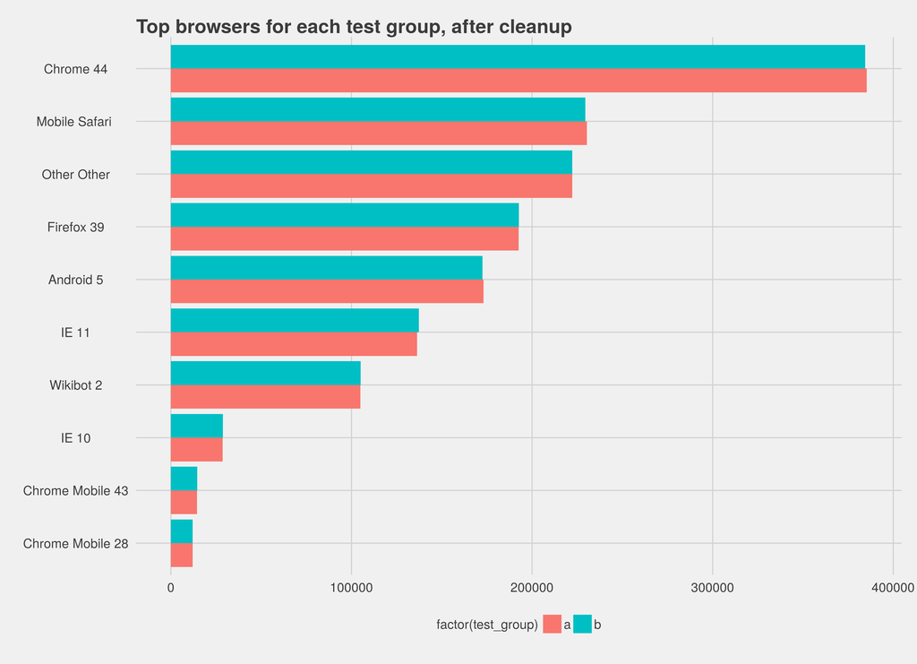

## Geography

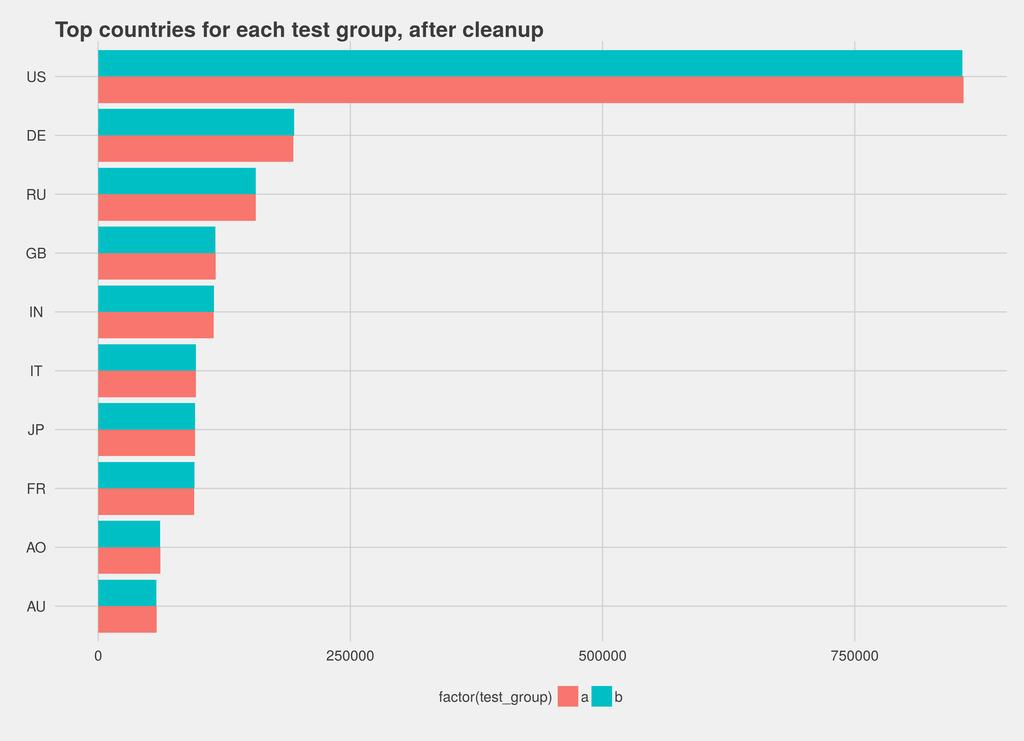

## Analysis

- So, sampling works - what next?
- Analyse the actual data, looking for a statistically significant variation in whether any results were returned (TRUE) versus none whatsoever (FALSE)
- Over to Mikhail!

## Exploratory data analysis

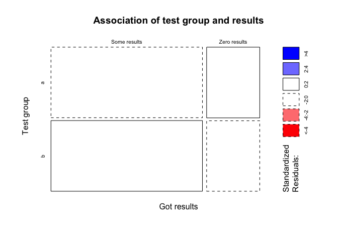

## Breakdown by class

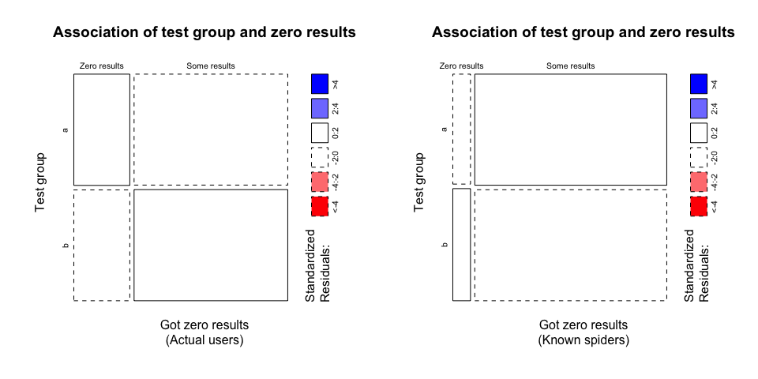

## Retrospective

### What worked

- All the key infrastructure for Inf future A/B tests is built, remarkably fast
- We're getting into the workflow of how to analyse the data that comes in.

### What didn't work

- The data format needs a ton of tweaks. Mikhail has taken the lead on drafting a proposal for a new format, which LGTM.
- Setting things up as a proper scientific experiment (Theory - Hypothesis - Experiment - Result) wasn't done. In future we need to include the Swifties in conversations about what we're doing + how + why if we want the results to be useful.
- Due to (2) we haven't advanced our knowledge around search, which is a big benefit of running these tests.